# UTS MPDW

Alfikri Ihsan

2023-10-06

1. Memanggil data

```r
library(ggplot2)
library(tsibble)
library(tseries)
library(MASS)
library(forecast)
library(TSA)
library(TTR)
library(aTSA)
library(graphics)

library(readxl)
dataa <- read_excel("Data UTS Fix.xlsx")


#menambahkan data dengan angka 818
data1 <- dataa$Data + 818
data1
```

```
##   [1] 4798 4857 4696 4627 4647 4616 4548 4523 4519 4600 4645 4577 4565 4484 4435
##  [16] 4456 4388 4416 4299 4359 4434 4307 4349 4521 4506 4371 4404 4448 4447 4422
##  [31] 4476 4408 4342 4741 4752 4599 4567 4596 4601 4514 4563 4470 4467 4402 4276
##  [46] 4222 4162 4228 4134 4217 4233 4278 4360 4182 4451 4368 4466 4402 4279 4305
##  [61] 4239 4275 4135 4072 4097 3954 3945 3945 3914 3946 3973 3987 3932 3930 3902
##  [76] 3845 3807 3811 3914 3798 3880 3829 3759 3592 3515 3488 3306 3290 3140 3161
##  [91] 3343 3372 3547 3423 3496 3531 3321 3200 3372 3317 3368 3290 3266 3295 3295
## [106] 3249 3350 3243 3385 3502 3444 3461 3439 3368 3264 3337 3434 3281 3302 3173
## [121] 3174 3120 3090 3142 3087 3117 3102 3097 3144 3169 3153 3178 3087 3093 3044
## [136] 3026 3009 2967 2944 2970 3005 2959 2907 2925 2849 2802 2801 2799 2834 2769
## [151] 2769
```

```r
#mengubah jadi data time series
data <- ts(data1)

#merupakan data harga jual gas bumi
```

2. Melihat secara eksploratif dengan plot time series

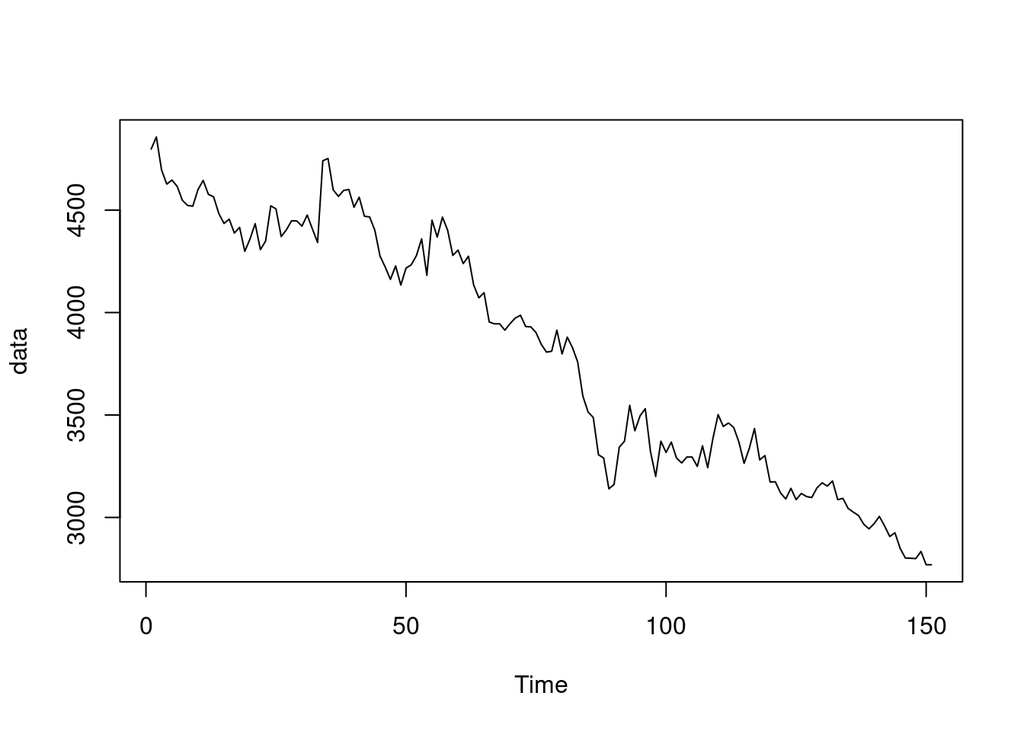

```r
plot.ts(data, )
```

dari hasil plot dapat dilihat bahwa data tidak stasioner dalam rataan namun stasioner dalam ragam

3. Melihat plot ACF

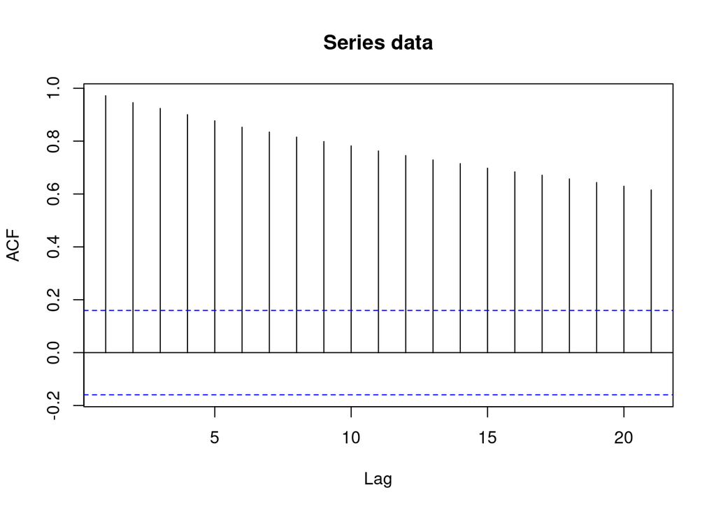

```r
acf(data)
```

terlihat dalam plot ACF bahwa data menurun secara tails off slowly yang artinya data tidak stasioner dalam rataan

4. uji ADF

```r
adf.test(data)
```

```
## Augmented Dickey-Fuller Test
## alternative: stationary
##
## Type 1: no drift no trend
##      lag   ADF p.value
## [1,]   0 -2.02  0.0436
## [2,]   1 -2.46  0.0157
## [3,]   2 -2.40  0.0183
## [4,]   3 -2.10  0.0368
## [5,]   4 -2.11  0.0360
## Type 2: with drift no trend
##      lag    ADF p.value
## [1,]   0 -0.775   0.775
## [2,]   1 -0.714   0.797
## [3,]   2 -0.450   0.889
## [4,]   3 -0.382   0.905
## [5,]   4 -0.374   0.906
## Type 3: with drift and trend
##      lag   ADF p.value
## [1,]   0 -3.34  0.0663
## [2,]   1 -2.79  0.2473
## [3,]   2 -2.65  0.3047
## [4,]   3 -2.95  0.1810
## [5,]   4 -2.94  0.1857
## ----
## Note: in fact, p.value = 0.01 means p.value <= 0.01
```

5. plot box cox

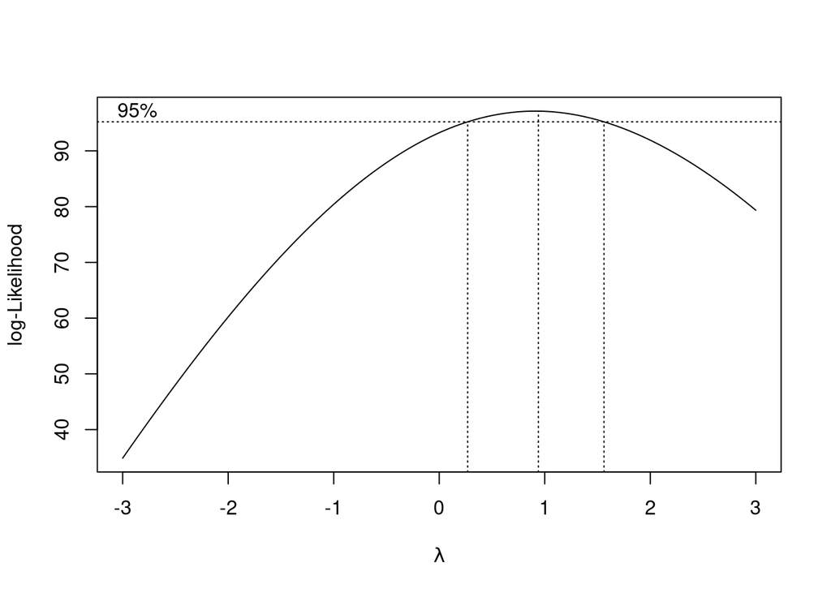

```r
index <- seq(1:151)
bc = boxcox(data~index, lambda = seq(-3,3,by=1))
```

```r
#Nilai Rounded Lambda
lambda <- bc$x[which.max(bc$y)]
lambda
```

```
## [1] 0.9393939
```

```r
#SK
bc$x[bc$y > max(bc$y) - 1/2 * qchisq(.95,1)]
```

```
##  [1] 0.2727273 0.3333333 0.3939394 0.4545455 0.5151515 0.5757576 0.6363636
##  [8] 0.6969697 0.7575758 0.8181818 0.8787879 0.9393939 1.0000000 1.0606061
## [15] 1.1212121 1.1818182 1.2424242 1.3030303 1.3636364 1.4242424 1.4848485
## [22] 1.5454545
```

dari plot box cox diperoleh lambda senilai 0.9393939 dan dapat dilihat bahwa terdapat angka 1 dalam plot box cox dalam selang 95%

6. Membagi data membagi data menjadi dua yaitu data latih dan data uji
7. Data Latih

```r
data1 <- data[1:120] |> ts()
mean(data1)
```

```
## [1] 4019.783
```

```r
var(data1)
```

```
## [1] 253615.2
```

```r
data2 <- data[120:151]
```

8. plot time series data latiih

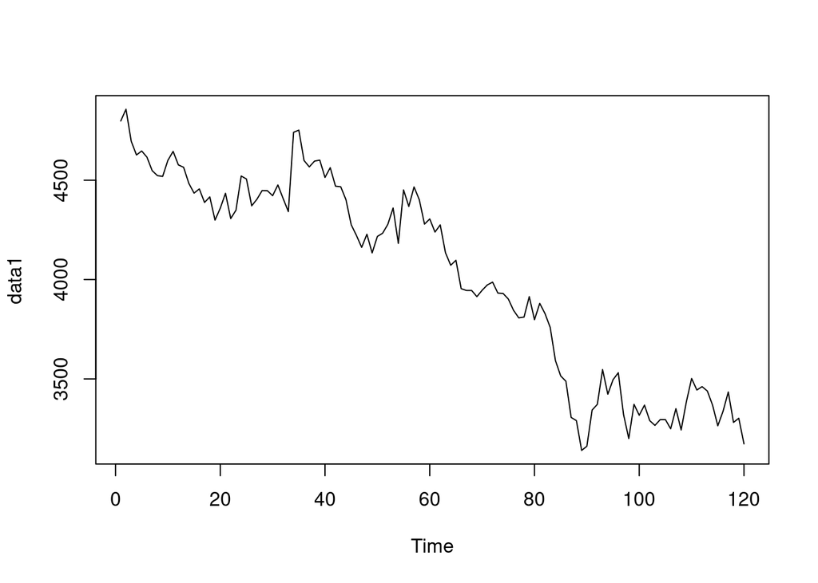

```r
plot.ts(data1)
```

9. cek kestationeran data latih plot acf

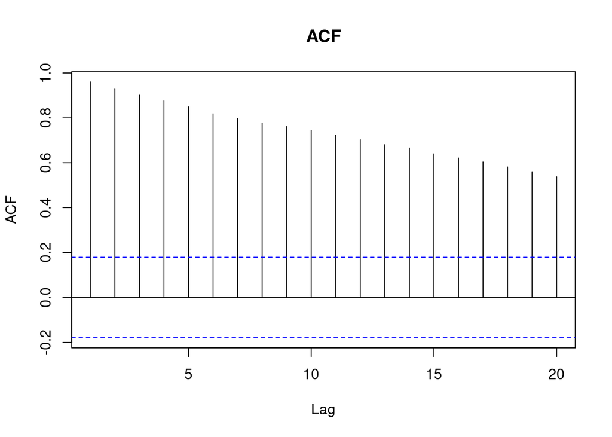

```r
acf(data1, main="ACF", lag.max=20)
```

data latih cenderung tails off slowly sehingga dapat disimpulkan data tidak stasioner dalam rataan

10 uji adf

```r
adf.test(data1)
```

```
## Augmented Dickey-Fuller Test
## alternative: stationary
##
## Type 1: no drift no trend
##      lag   ADF p.value
## [1,]   0 -1.67  0.0908
## [2,]   1 -2.02  0.0438
## [3,]   2 -1.96  0.0493
## [4,]   3 -1.72  0.0836
## [5,]   4 -1.72  0.0833
## Type 2: with drift no trend
##      lag    ADF p.value
## [1,]   0 -0.922   0.724
## [2,]   1 -0.868   0.743
## [3,]   2 -0.599   0.837
## [4,]   3 -0.518   0.866
## [5,]   4 -0.514   0.867
## Type 3: with drift and trend
##      lag   ADF p.value
## [1,]   0 -2.94   0.186
## [2,]   1 -2.45   0.387
## [3,]   2 -2.31   0.445
## [4,]   3 -2.56   0.340
## [5,]   4 -2.56   0.341
## ----
## Note: in fact, p.value = 0.01 means p.value <= 0.01
```